# Analyse des présences et des absences au conseil municipal de Lannion

IUT de Lannion

19/11/2021

Nous avons recensé les présences et les absences aux conseils municipaux de Lannion à partir des comptes rendus publiés sous format pdf sur le site de la [ville de Lannion](https://www.lannion.bzh/mairie/conseil-municipal).  
Au total, 12 conseils municipaux sont analysés ici sur une période courant du 25 mai 2020 au 8 novembre 2021.  
**Avertissement** Le décompte des présences et des absences aux conseils municpaux est réalisé à chaque début de séance. Ainsi des conseillers municipaux peuvent être déclarés absents ou ayant donné procuration à l’ouverture de la séance tout en ayant pourtant assisté à une partie du conseil, s’ils sont arrivés plus tard pendant la séance. Ces exceptions ne sont pas comptabilisées dans la base de données.

# **Répartition globale**

## **Pour tous les conseillers municpaux**

Au total, notre base de données compte 360 présences et 33 absences ou procurations. Le nombre d’absences représente ainsi 8.4% de l’ensemble.

En moyenne, le taux de présence par conseil municipal est de **91.62%**.  
Le conseil municpal qui a compté le plus faible taux de présence est celui du **2021-09-27** avec un taux de **75.76%**. Le conseil municpal qui a compté le plus fort taux de présence est celui du **2021-05-28** avec un taux de **100%**.

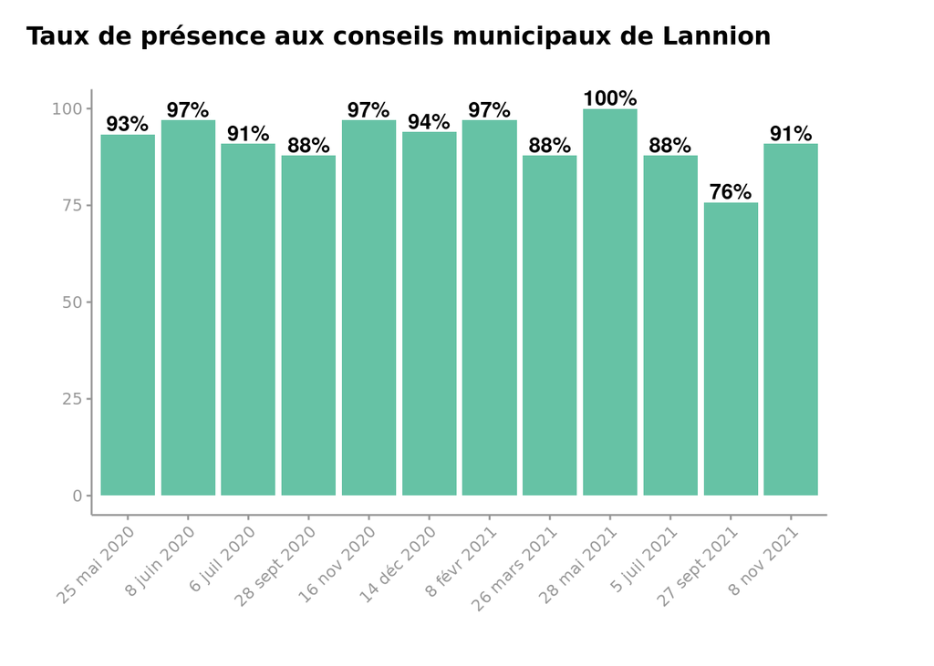

## **Par conseiller municipal**

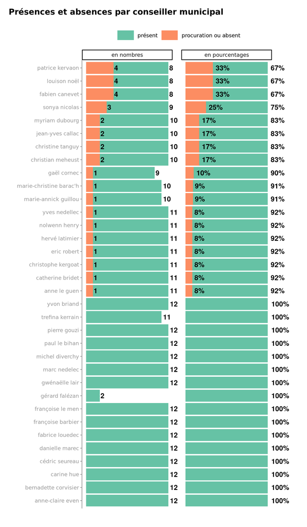

# **Répartition par étiquette et nuance politique**

## **Pour tous les conseillers municpaux**

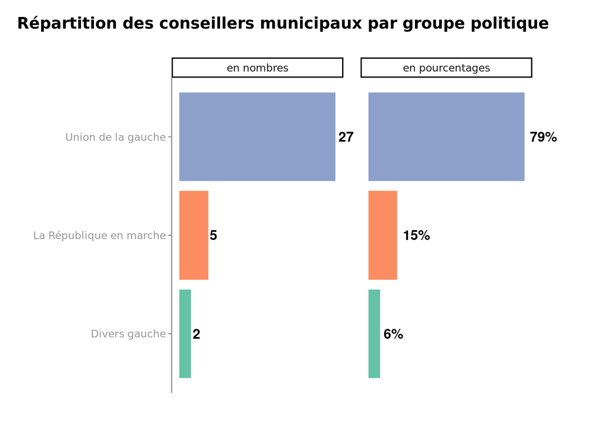

Présence moyenne des groupes politiques par conseil municipal :  
- dans le groupe **Divers gauche**, le taux de présence moyen de **87.5%**  
- dans le groupe **La République en marche**, le taux de présence moyen de **87.5%**  
- dans le groupe **Union de la gauche**, le taux de présence moyen de **92.52%**

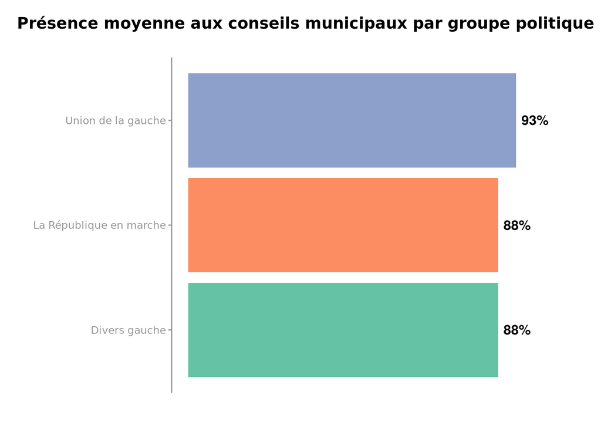

## **Par conseiller municipal**

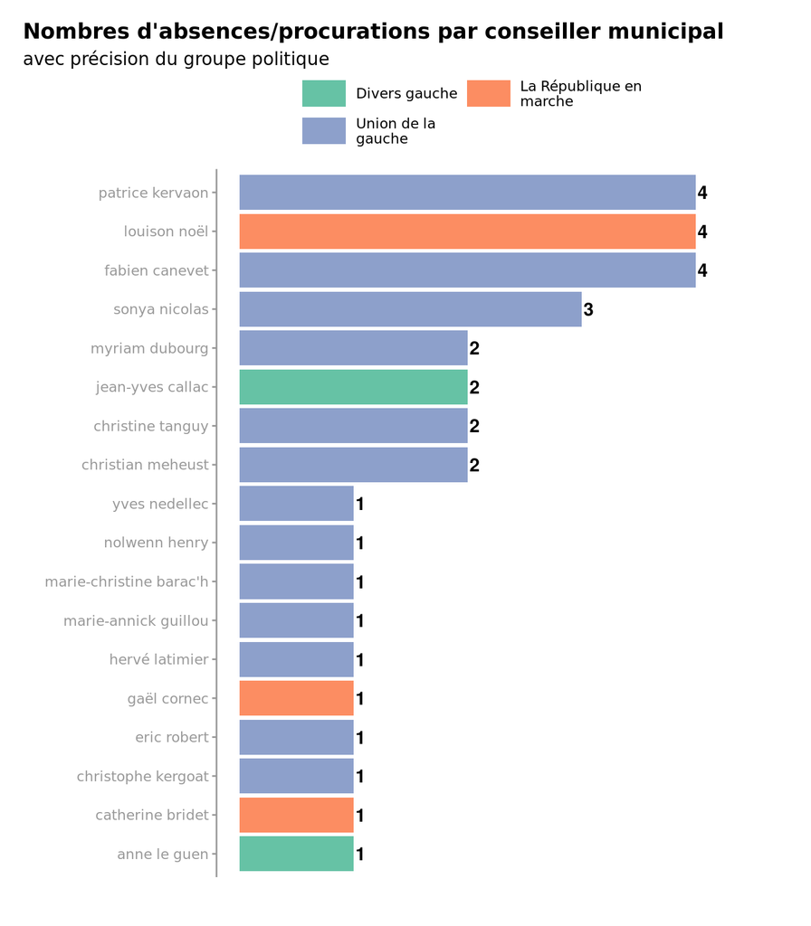

# **Répartition par catégorie socio professionnelle**

## **Pour tous les conseillers municpaux**

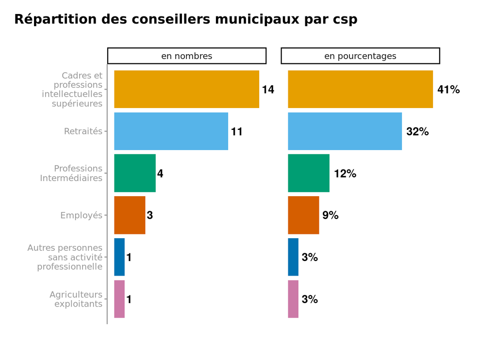

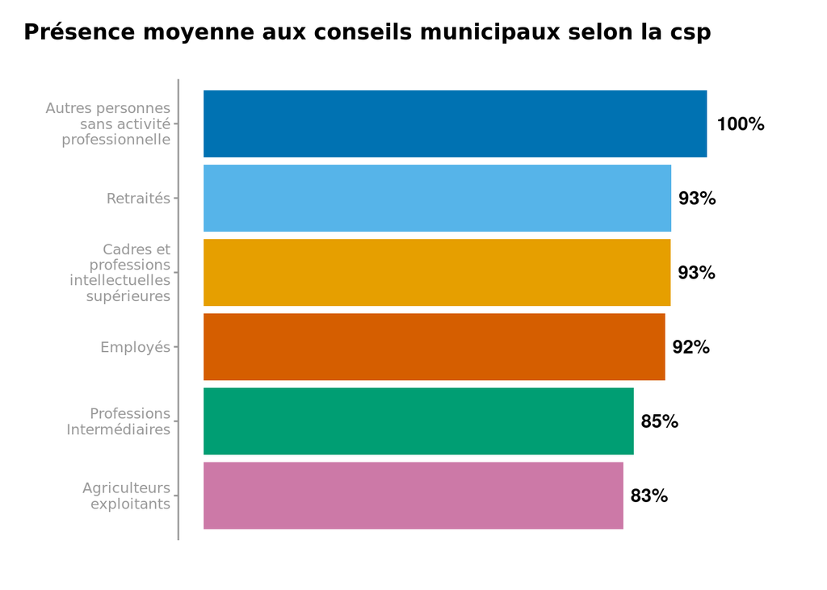

## **Par conseiller municipal**

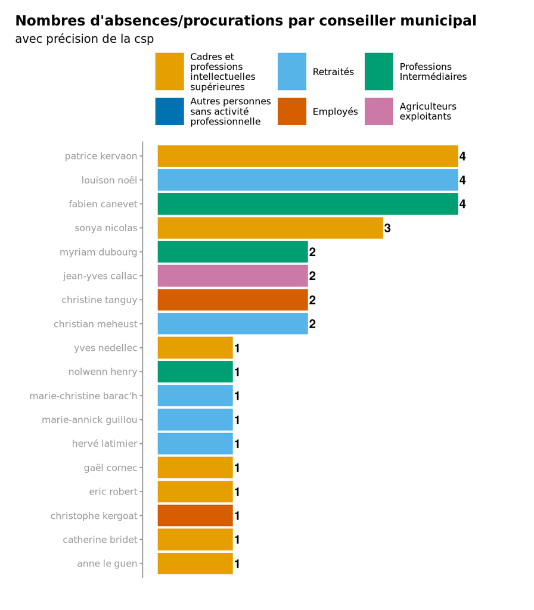